# Project: Investigate a Dataset (TMDb_Movies Dataset)

- Introduction
- Data Wrangling
- Exploratory Data Analysis
- Conclusions

## Introduction

> For this project I have chosen to look at the TMDB dataset. This data was provided as part of the Udacity Data Analysis Nanodegree and originated from Kaggle.

> Questions:
> 1. Distribution of Popularity in Different Revenue Levels in Recent Five Years.
> 2. Top Movies Based on their Revenue.
> 3. Movies with longest and shortest runtime values.
> 4. Which movie had the greatest and least budget?
> 5. Average runtime of all the movies.
> 6. Number of movies released year by year.
> 7. Average Budget of Movies.
> 8. Average budget (with respest to the profitable movies)
> 9. Popularity over the years.
> 10. What is the relationship between runtime and vote average?

```python
# Import statements for all of the packages that I plan to use.
import pandas as pd
import numpy as np
import matplotlib.pyplot as plt
import seaborn as sns
% matplotlib inline
```

## Data Wrangling

### Explore General Properties of the Dataset

### Reading the Data:

```python
# Load your data

data = pd.read_csv('tmdb-movies.csv')
```

```python
#printing first five rows with defined columns of tmdb-movies database
data.head()
```

|  | id | imdb_id | popularity | budget | revenue | original_title | cast | homepage | director | tagline | ... | overview | runtime | genres | production_companies | release_date | vote_count | vote_average | release_year | budget_adj | revenue_adj |
| --- | --- | --- | --- | --- | --- | --- | --- | --- | --- | --- | --- | --- | --- | --- | --- | --- | --- | --- | --- | --- | --- |
| 0 | 135397 | tt0369610 | 32.985763 | 150000000 | 1513528810 | Jurassic World | Chris Pratt\|Bryce Dallas Howard\|Irrfan Khan\|Vi... | http://www.jurassicworld.com/ | Colin Trevorrow | The park is open. | ... | Twenty-two years after the events of Jurassic ... | 124 | Action\|Adventure\|Science Fiction\|Thriller | Universal Studios\|Amblin Entertainment\|Legenda... | 6/9/15 | 5562 | 6.5 | 2015 | 1.379999e+08 | 1.392446e+09 |
| 1 | 76341 | tt1392190 | 28.419936 | 150000000 | 378436354 | Mad Max: Fury Road | Tom Hardy\|Charlize Theron\|Hugh Keays-Byrne\|Nic... | http://www.madmaxmovie.com/ | George Miller | What a Lovely Day. | ... | An apocalyptic story set in the furthest reach... | 120 | Action\|Adventure\|Science Fiction\|Thriller | Village Roadshow Pictures\|Kennedy Miller Produ... | 5/13/15 | 6185 | 7.1 | 2015 | 1.379999e+08 | 3.481613e+08 |
| 2 | 262500 | tt2908446 | 13.112507 | 110000000 | 295238201 | Insurgent | Shailene Woodley\|Theo James\|Kate Winslet\|Ansel... | http://www.thedivergentseries.movie/#insurgent | Robert Schwentke | One Choice Can Destroy You | ... | Beatrice Prior must confront her inner demons ... | 119 | Adventure\|Science Fiction\|Thriller | Summit Entertainment\|Mandeville Films\|Red Wago... | 3/18/15 | 2480 | 6.3 | 2015 | 1.012000e+08 | 2.716190e+08 |
| 3 | 140607 | tt2488496 | 11.173104 | 200000000 | 2068178225 | Star Wars: The Force Awakens | Harrison Ford\|Mark Hamill\|Carrie Fisher\|Adam D... | http://www.starwars.com/films/star-wars-episod... | J.J. Abrams | Every generation has a story. | ... | Thirty years after defeating the Galactic Empi... | 136 | Action\|Adventure\|Science Fiction\|Fantasy | Lucasfilm\|Truenorth Productions\|Bad Robot | 12/15/15 | 5292 | 7.5 | 2015 | 1.839999e+08 | 1.902723e+09 |
| 4 | 168259 | tt2820852 | 9.335014 | 190000000 | 1506249360 | Furious 7 | Vin Diesel\|Paul Walker\|Jason Statham\|Michelle ... | http://www.furious7.com/ | James Wan | Vengeance Hits Home | ... | Deckard Shaw seeks revenge against Dominic Tor... | 137 | Action\|Crime\|Thriller | Universal Pictures\|Original Film\|Media Rights ... | 4/1/15 | 2947 | 7.3 | 2015 | 1.747999e+08 | 1.385749e+09 |

5 rows × 21 columns

```python
data.info()
```

```
<class 'pandas.core.frame.DataFrame'>
RangeIndex: 10866 entries, 0 to 10865
Data columns (total 21 columns):
id                      10866 non-null int64
imdb_id                 10856 non-null object
popularity              10866 non-null float64
budget                  10866 non-null int64
revenue                 10866 non-null int64
original_title          10866 non-null object
cast                    10790 non-null object
homepage                2936 non-null object
director                10822 non-null object
tagline                 8042 non-null object
keywords                9373 non-null object
overview                10862 non-null object
runtime                 10866 non-null int64
genres                  10843 non-null object
production_companies    9836 non-null object
release_date            10866 non-null object
vote_count              10866 non-null int64
vote_average            10866 non-null float64
release_year            10866 non-null int64
budget_adj              10866 non-null float64
revenue_adj             10866 non-null float64
dtypes: float64(4), int64(6), object(11)
memory usage: 1.7+ MB
```

From the table above, there are totally 10866 entries and total 21 columns. Each data format is reasonable, and there exists some null value in the imdb_id, cast, director, overview and genres columns, but just in tiny amounts, so I decided to drop them. However, some columns are with a lot of null values like homepage, tagline, keywords and production_companies, especially the homepage and tagline column are even not necessary for answering the questions, so I decide to drop both of the columns at this stage, and kept the keywords and production_companies.

```python
for_rows=['imdb_id','cast','director','overview','genres']
data.dropna(subset=for_rows, inplace=True)
```

```python
columns=['homepage','tagline']
data.drop(columns, axis=1, inplace=True)
```

```python
#explore dataset
data.describe()
```

|  | id | popularity | budget | revenue | runtime | vote_count | vote_average | release_year | budget_adj | revenue_adj |
| --- | --- | --- | --- | --- | --- | --- | --- | --- | --- | --- |
| count | 10725.000000 | 10725.000000 | 1.072500e+04 | 1.072500e+04 | 10725.000000 | 10725.000000 | 10725.000000 | 10725.000000 | 1.072500e+04 | 1.072500e+04 |
| mean | 65182.327925 | 0.652852 | 1.481473e+07 | 4.034253e+07 | 102.502471 | 219.933054 | 5.964317 | 2001.255012 | 1.777804e+07 | 5.203541e+07 |
| std | 91470.421976 | 1.005025 | 3.107129e+07 | 1.176814e+08 | 30.458857 | 578.955633 | 0.930166 | 12.822147 | 3.447315e+07 | 1.454606e+08 |
| min | 5.000000 | 0.000188 | 0.000000e+00 | 0.000000e+00 | 0.000000 | 10.000000 | 1.500000 | 1960.000000 | 0.000000e+00 | 0.000000e+00 |
| 25% | 10546.000000 | 0.210766 | 0.000000e+00 | 0.000000e+00 | 90.000000 | 17.000000 | 5.400000 | 1995.000000 | 0.000000e+00 | 0.000000e+00 |
| 50% | 20309.000000 | 0.387304 | 0.000000e+00 | 0.000000e+00 | 99.000000 | 39.000000 | 6.000000 | 2006.000000 | 0.000000e+00 | 0.000000e+00 |
| 75% | 73937.000000 | 0.721548 | 1.600000e+07 | 2.500526e+07 | 112.000000 | 148.000000 | 6.600000 | 2011.000000 | 2.113258e+07 | 3.476553e+07 |
| max | 417859.000000 | 32.985763 | 4.250000e+08 | 2.781506e+09 | 900.000000 | 9767.000000 | 9.200000 | 2015.000000 | 4.250000e+08 | 2.827124e+09 |

### Data Cleaning

In this part a trivial data cleaning will be performed.

```python
#removing rows where revenue_adj and budget_adj is equal to zero

data = data[data.budget_adj != 0]
data = data[data.revenue_adj != 0]
```

### Removing the duplicacy in the rows(if any).

> Lets see how many entries we have in the database

```python
rows,col=data.shape
print('There are {} total entries of movies and {} no. of columns in it.'.format(rows, col))
```

```
There are 3850 total entries of movies and 19 no. of columns in it.
```

> Now removing the duplicate rows if any!

```python
data.drop_duplicates(inplace=True)
rows, col = data.shape
print('There are now {} total entries of movies and {} no. of columns in it.'.format(rows, col))
```

```
There are now 3849 total entries of movies and 19 no. of columns in it.
```

> So there was a duplicate row and it has been removed now.

## Exploratory Data Analysis

### Question 1 : Distribution of Popularity in Different Revenue Levels in Recent Five Years

The aim is to find out the distribution of popularit in terms of different revenue levels. This means I can see what popularity corresponds to which revenue levels. Due to the revenue data containing a wide range, to be more specific, I divided the revenue data into four levels: Low', 'Medium', 'Moderately High', 'High' according to their quartile. Also I choose the recent five years data to dicuss in order to focus on the current data feature.

For the further usage of the level-diveded procedure with quartile, I build a cut_into_quantile function to divided data into four levels according to their quartile: 'Low', 'Medium', 'Moderately High', 'High'.

The cut_into_quantile function-

```python
# quartile function
def cut_into_quantile(dfname ,column_name):
# find quartile, max and min values
    min_value = dfname[column_name].min()
    first_quantile = dfname[column_name].describe()[4]
    second_quantile = dfname[column_name].describe()[5]
    third_quantile = dfname[column_name].describe()[6]
    max_value = dfname[column_name].max()
# Bin edges that will be used to "cut" the data into groups
    bin_edges = [ min_value, first_quantile, second_quantile, third_quantile, max_value]
# Labels for the four budget level groups
    bin_names = [ 'Low', 'Medium', 'Moderately High', 'High']
# Creates budget_levels column
    name = '{}_levels'.format(column_name)
    dfname[name] = pd.cut(dfname[column_name], bin_edges, labels=bin_names, include_lowest = True)
    return dfname
```

```python
#choose the recent five years
dfyear =[2011,2012,2013,2014,2015]
#creat a empty dataframe,df_q2
df_q2 = pd.DataFrame()

#for each year, do the following procedure
for year in dfyear:
    dfn = data.query('release_year == "%s"' % year) # first filter dataframe with the selected year
    dfn2 = cut_into_quantile(dfn,'revenue') #apply the cut_into_quantile with the selected frame, store it to dfn2
    df_q2 = df_q2.append(dfn2) #append dfn2 to df_q2
df_q2.info()
```

```
<class 'pandas.core.frame.DataFrame'>
Int64Index: 861 entries, 3372 to 583
Data columns (total 20 columns):
id                      861 non-null int64
imdb_id                 861 non-null object
popularity              861 non-null float64
budget                  861 non-null int64
revenue                 861 non-null int64
original_title          861 non-null object
cast                    861 non-null object
director                861 non-null object
keywords                818 non-null object
overview                861 non-null object
runtime                 861 non-null int64
genres                  861 non-null object
production_companies    857 non-null object
release_date            861 non-null object
vote_count              861 non-null int64
vote_average            861 non-null float64
release_year            861 non-null int64
budget_adj              861 non-null float64
revenue_adj             861 non-null float64
revenue_levels          861 non-null category
dtypes: category(1), float64(4), int64(6), object(9)
memory usage: 135.6+ KB
```

[output not shown]

Now we can see we have created a revenue_levels column.

Then use the dataset to explore the popularity in each level each year.

```python
# group the dataframe we created above with each revenue levels in each year, find the popularity meadian
dfq2_summary = df_q2.groupby(['release_year','revenue_levels']).median()
dfq2_summary.tail(8)
```

| release_year | revenue_levels | id | popularity | budget | revenue | runtime | vote_count | vote_average | budget_adj | revenue_adj |
| --- | --- | --- | --- | --- | --- | --- | --- | --- | --- | --- |
| 2014 | Low | 241543.5 | 0.751624 | 5500000.0 | 2440417.5 | 100.0 | 193.0 | 6.15 | 5.066001e+06 | 2.247847e+06 |
|  | Medium | 227735.0 | 0.981740 | 15000000.0 | 34077920.0 | 106.0 | 377.0 | 6.20 | 1.381637e+07 | 3.138887e+07 |
|  | Moderately High | 216282.0 | 1.805954 | 40000000.0 | 106645357.0 | 106.0 | 720.0 | 6.20 | 3.684364e+07 | 9.823008e+07 |
|  | High | 138103.0 | 3.813740 | 120000000.0 | 362637473.0 | 113.0 | 2169.0 | 6.80 | 1.105309e+08 | 3.340221e+08 |
| 2015 | Low | 273688.0 | 0.695024 | 9250000.0 | 3172497.0 | 101.5 | 146.5 | 5.70 | 8.509996e+06 | 2.918696e+06 |
|  | Medium | 276254.0 | 1.696682 | 16000000.0 | 36738078.5 | 106.0 | 470.5 | 6.20 | 1.471999e+07 | 3.379902e+07 |
|  | Moderately High | 267442.5 | 2.035523 | 30000000.0 | 94629376.0 | 114.0 | 720.0 | 6.30 | 2.759999e+07 | 8.705899e+07 |
|  | High | 215385.5 | 5.184985 | 103500000.0 | 350398577.0 | 120.5 | 1882.0 | 6.70 | 9.521996e+07 | 3.223665e+08 |

```python
dfq2_summary.reset_index(inplace=True)
```

### Then plot a bar chart.

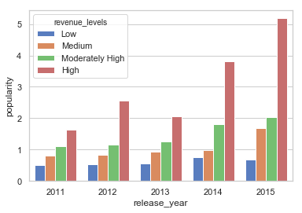

```python
sns.set(style="whitegrid")

# Draw a nested barplot to show revenue_levels for year and popularity
g = sns.barplot(x="release_year", y="popularity", hue="revenue_levels", data=dfq2_summary, palette="muted")
```

### We can see that movies with higher revenue level are with higher popularity in recent five years.

We can see that revenue level has postive relation with popularity. The result is reasonable. So according to the result from the data analysis, I infer that a high revenue movie is always with a higher popularity than movies with lower revenue levels.

### Question 2 : Top Movies Based on their Revenue

The following code snippet produce the barplot representing the top 10 movies based on their adjusted revenue.

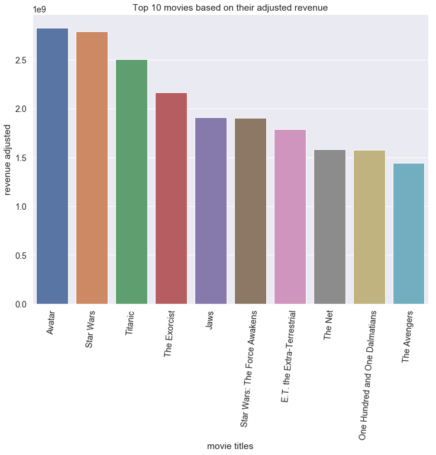

```python
#Top Movies Based on their Revenue
revenue_dict = {}


movies_and_revenue = data[["original_title", "revenue_adj"]]


#print(movies_and_revenue.sort_values(by="revenue_adj", ascending=False).head(10))
#print("\n")
#print(movies_and_budget.sort_values(by = "budget_adj", ascending = False).head(10))

sns.set(rc={'figure.figsize':(12,9)}, font_scale=1.3)


ax = sns.barplot(
    movies_and_revenue.sort_values(by = "revenue_adj", ascending=False).head(10).original_title,
    movies_and_revenue.sort_values(by = "revenue_adj", ascending=False).head(10).revenue_adj)



#rotate x-axis' text
for item in ax.get_xticklabels():
    item.set_rotation(85)


ax.set(xlabel='movie titles', ylabel='revenue adjusted', title = 'Top 10 movies based on their adjusted revenue')
plt.show()
```

### Question 3 : Movies with longest and shortest runtime values

```python
def calculate(column):
    #for highest runtime
    high= data[column].idxmax()
    high_details=pd.DataFrame(data.loc[high])

    #for lowest runtime
    low= data[column].idxmin()
    low_details=pd.DataFrame(data.loc[low])

    #collectin data in one place
    info=pd.concat([high_details, low_details], axis=1)

    return info
```

```python
calculate('runtime')
```

|  | 2107 | 5162 |
| --- | --- | --- |
| id | 43434 | 24914 |
| imdb_id | tt1321865 | tt0368574 |
| popularity | 0.534192 | 0.208637 |
| budget | 18000000 | 10 |
| revenue | 871279 | 5 |
| original_title | Carlos | Kid's Story |
| cast | Edgar Ramírez\|Alexander Scheer\|Fadi Abi Samra... | Clayton Watson\|Keanu Reeves\|Carrie-Anne Moss\|K... |
| director | Olivier Assayas | Shinichiro Watanabe |
| keywords | gun\|car bomb\|tv mini-series\|terrorism\|opec | NaN |
| overview | The story of Venezuelan revolutionary, Ilich R... | A high school student is haunted by thoughts o... |
| runtime | 338 | 15 |
| genres | Crime\|Drama\|Thriller\|History | Science Fiction\|Animation |
| production_companies | Egoli Tossell Film AG\|Canal+\|Arte France\|Films... | Studio 4°C |
| release_date | 5/19/10 | 6/2/03 |
| vote_count | 35 | 16 |
| vote_average | 6.2 | 6.8 |
| release_year | 2010 | 2003 |
| budget_adj | 1.8e+07 | 11.8535 |
| revenue_adj | 871279 | 5.92676 |

> Column with id 2107 shows the longest runtime i.e 338 minutes.

> Whereas the column with id 5162 shows the shortest runtime i.e 15 minutes

### Question 4: Which movie had the greatest and least budget?

```python
#as our calculations seems to be same as previous one for different column, lets call the function by passing desired argument
calculate('budget_adj')
```

|  | 2244 | 3581 |
| --- | --- | --- |
| id | 46528 | 59296 |
| imdb_id | tt1032751 | tt1436559 |
| popularity | 0.25054 | 0.52043 |
| budget | 425000000 | 1 |
| revenue | 11087569 | 1378 |
| original_title | The Warrior's Way | Love, Wedding, Marriage |
| cast | Kate Bosworth\|Jang Dong-gun\|Geoffrey Rush\|Dann... | Mandy Moore\|Kellan Lutz\|Jessica Szohr\|Autumn F... |
| director | Sngmoo Lee | Dermot Mulroney |
| keywords | assassin\|small town\|revenge\|deception\|super speed | wedding vows\|marriage\|love |
| overview | An Asian assassin (Dong-gun Jang) is forced to... | A happy newlywed marriage counselor's views on... |
| runtime | 100 | 90 |
| genres | Adventure\|Fantasy\|Action\|Western\|Thriller | Comedy\|Romance |
| production_companies | Boram Entertainment Inc. | 120dB Films\|Scion Films\|Voodoo Production Serv... |
| release_date | 12/2/10 | 6/3/11 |
| vote_count | 74 | 55 |
| vote_average | 6.4 | 5.3 |
| release_year | 2010 | 2011 |
| budget_adj | 4.25e+08 | 0.969398 |
| revenue_adj | 1.10876e+07 | 1335.83 |

This is Interesting. Same in format as above dataframes, we can see that The Warriors Way had the highest budget of all movies in the dataset of about \$425M. This same movie also had a great loss. So it makes sense that having the highest budget in all makes the film more harder to have higher revenues and earn more profits.

And the least budget of all, the Love, Wedding, Marriage movie of \$0.96 has made me thinking how can a movie with 90 min of runtime manage with such low budget! Also making revenue of \$1335 and earning a profit \$1334.04, this may be a local movie release. Because it's kind of impossible to have such low budget and earning low revenues if it has released internationally.

### Question 5 : Average runtime of all the movies.

```python
# defining a function to find average of a column
def avg_fun(column):
    return data[column].mean()
```

```python
#calling above function
avg_fun('runtime')
```

```
109.21745908028059
```

> So the average runtime a movie is 109 minutes. Lets analyse it in a visual form i.e. by graphical approach.

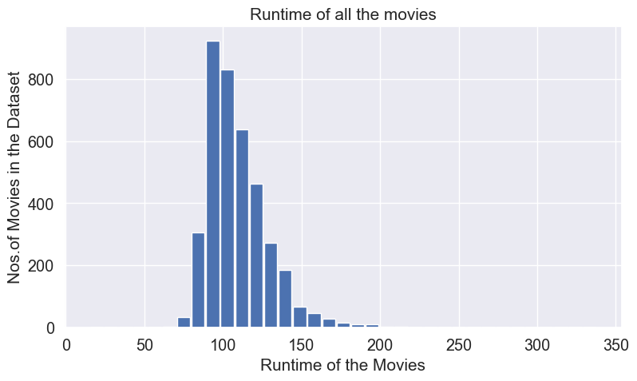

```python
#plotting a histogram of runtime of movies

#giving the figure size(width, height)
plt.figure(figsize=(9,5), dpi = 100)

#On x-axis
plt.xlabel('Runtime of the Movies', fontsize = 15)
#On y-axis
plt.ylabel('Nos.of Movies in the Dataset', fontsize=15)
#Name of the graph
plt.title('Runtime of all the movies', fontsize=15)

#giving a histogram plot
plt.hist(data['runtime'], rwidth = 0.9, bins =35)
#displays the plot
plt.show()
```

> The distribution of the above formed graph is positively skewed or right skewed! Most of the movies are timed between 80 to 115 minutes. Almost 1000 and more no.of movies fall in this criteria.

> Lets analyse more about runtime of the movie using different kind of plots i.e Box Plot and Data Point Plot

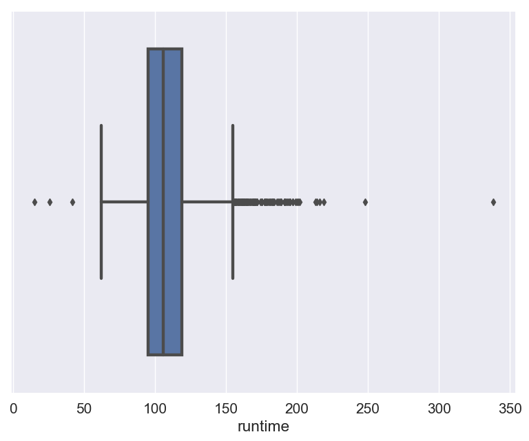

```python
#The First plot is box plot of the runtime of the movies
plt.figure(figsize=(9,7), dpi = 105)

#using seaborn to generate the boxplot
sns.boxplot(data['runtime'], linewidth = 3)
#diplaying the plot
plt.show()
```

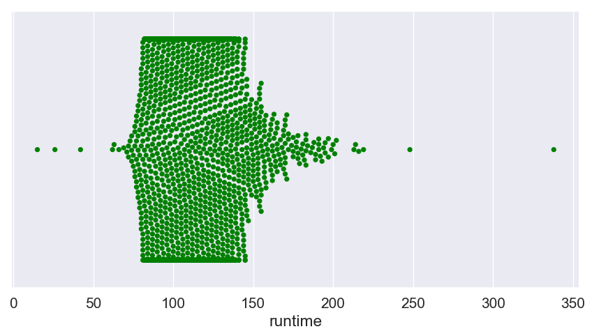

```python
#The Second plots is the data points plot of runtime of movies

plt.figure(figsize=(10,5), dpi = 105)
#using seaborn to generate the plot
sns.swarmplot(data['runtime'], color = 'green')
#displaying the plot
plt.show()
```

```python
#getting specific runtime
data['runtime'].describe()
```

```
count    3849.000000
mean      109.217459
std        19.914141
min        15.000000
25%        95.000000
50%       106.000000
75%       119.000000
max       338.000000
Name: runtime, dtype: float64
```

> Thats amazing!! The plot generated above give a visual of complete distribution of runtime of movies by plotting the points againts their respective position in the ditribution

> Coming to our first plot i.e. box-plot, It gives us an overall idea of how spreaded the distribution is in case of runtime of the movies. We also get the outliers her if you carefully observe the plot.

> By looking at both the plot and calculations, we can conclude that..
> 1. 25% of movies have a runtime of less than 95 minutes.
> 2. 50% of movies have a runtime of less than 106 minutes. (median)
> 3. 75% of movies have a runtime of less than 119 minutes.

### Question 6 : Number of movies released year by year

**In question 6, I am going to find out the number of movie released year by year.**

First, use group by release year and count the number of movie released in each year.

```python
movie_count = data.groupby('release_year').count()['id']
movie_count.head()
```

```
release_year
1960     5
1961    10
1962     7
1963     6
1964     7
Name: id, dtype: int64
```

Then visualise the result.

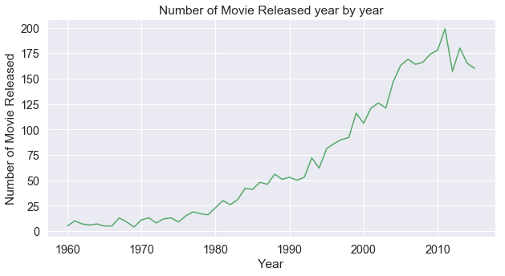

```python
#set style
sns.set_style('darkgrid')
#set x, y axis data
# x is movie release year
x = movie_count.index
# y is number of movie released
y = movie_count
#set size
plt.figure(figsize=(10, 5))
#plot line chart
plt.plot(x, y, color = 'g', label = 'mean')
#set title and labels
plt.title('Number of Movie Released year by year')
plt.xlabel('Year')
plt.ylabel('Number of Movie Released');
```

### Question 7 : Average Budget of Movies.

```python
avg_fun('budget_adj')
```

```
44293601.63666381
```

The average budget of movies is around `$44M dollars`.

### Question 8 : Average Budget of Movies. (With respect to the profitable movies)

> **With respect to the profitable movies.**

> Before moving further we need to clean our data again. We will be considering only those movies who have earned a significant amount of profit.

> **So lets fix this amount to 50 million dollar.**

```python
#insert function with three parameters(index of the column in the dataset, name of the column, value to be inserted)
data.insert(2,'profit_earned_adj',data['revenue_adj']-data['budget_adj'])

#previewing the changes in the dataset
data.head(2)
```

|  | id | imdb_id | profit_earned_adj | popularity | budget | revenue | original_title | cast | director | keywords | overview | runtime | genres | production_companies | release_date | vote_count | vote_average | release_year | budget_adj | revenue_adj |
| --- | --- | --- | --- | --- | --- | --- | --- | --- | --- | --- | --- | --- | --- | --- | --- | --- | --- | --- | --- | --- |
| 0 | 135397 | tt0369610 | 1.254446e+09 | 32.985763 | 150000000 | 1513528810 | Jurassic World | Chris Pratt\|Bryce Dallas Howard\|Irrfan Khan\|Vi... | Colin Trevorrow | monster\|dna\|tyrannosaurus rex\|velociraptor\|island | Twenty-two years after the events of Jurassic ... | 124 | Action\|Adventure\|Science Fiction\|Thriller | Universal Studios\|Amblin Entertainment\|Legenda... | 6/9/15 | 5562 | 6.5 | 2015 | 1.379999e+08 | 1.392446e+09 |
| 1 | 76341 | tt1392190 | 2.101614e+08 | 28.419936 | 150000000 | 378436354 | Mad Max: Fury Road | Tom Hardy\|Charlize Theron\|Hugh Keays-Byrne\|Nic... | George Miller | future\|chase\|post-apocalyptic\|dystopia\|australia | An apocalyptic story set in the furthest reach... | 120 | Action\|Adventure\|Science Fiction\|Thriller | Village Roadshow Pictures\|Kennedy Miller Produ... | 5/13/15 | 6185 | 7.1 | 2015 | 1.379999e+08 | 3.481613e+08 |

```python
#selecting the movies having profit $50M or more
profit_data = data[data['profit_earned_adj'] >= 50000000]

#reindexing new data
profit_data.index = range(len(profit_data))

#we will start from 1 instead of 0
profit_data.index = profit_data.index + 1

#printing the changed dataset
profit_data.head(3)
```

|  | id | imdb_id | profit_earned_adj | popularity | budget | revenue | original_title | cast | director | keywords | overview | runtime | genres | production_companies | release_date | vote_count | vote_average | release_year | budget_adj | revenue_adj |
| --- | --- | --- | --- | --- | --- | --- | --- | --- | --- | --- | --- | --- | --- | --- | --- | --- | --- | --- | --- | --- |
| 1 | 135397 | tt0369610 | 1.254446e+09 | 32.985763 | 150000000 | 1513528810 | Jurassic World | Chris Pratt\|Bryce Dallas Howard\|Irrfan Khan\|Vi... | Colin Trevorrow | monster\|dna\|tyrannosaurus rex\|velociraptor\|island | Twenty-two years after the events of Jurassic ... | 124 | Action\|Adventure\|Science Fiction\|Thriller | Universal Studios\|Amblin Entertainment\|Legenda... | 6/9/15 | 5562 | 6.5 | 2015 | 1.379999e+08 | 1.392446e+09 |
| 2 | 76341 | tt1392190 | 2.101614e+08 | 28.419936 | 150000000 | 378436354 | Mad Max: Fury Road | Tom Hardy\|Charlize Theron\|Hugh Keays-Byrne\|Nic... | George Miller | future\|chase\|post-apocalyptic\|dystopia\|australia | An apocalyptic story set in the furthest reach... | 120 | Action\|Adventure\|Science Fiction\|Thriller | Village Roadshow Pictures\|Kennedy Miller Produ... | 5/13/15 | 6185 | 7.1 | 2015 | 1.379999e+08 | 3.481613e+08 |
| 3 | 262500 | tt2908446 | 1.704191e+08 | 13.112507 | 110000000 | 295238201 | Insurgent | Shailene Woodley\|Theo James\|Kate Winslet\|Ansel... | Robert Schwentke | based on novel\|revolution\|dystopia\|sequel\|dyst... | Beatrice Prior must confront her inner demons ... | 119 | Adventure\|Science Fiction\|Thriller | Summit Entertainment\|Mandeville Films\|Red Wago... | 3/18/15 | 2480 | 6.3 | 2015 | 1.012000e+08 | 2.716190e+08 |

```python
#New function to find average
def profit_avg(column):
    return profit_data[column].mean()
```

```python
profit_avg('budget_adj')
```

```
64357774.22141103
```

> So the movies having profit of 50 million dollar and more have an average budget of 64 million dollar.

### Question 9 : Popularity over the years.

To analyse the question, I computed the mean of popularity in each year, and then plotted lines to see the trends. Moreever, since the popularity has no upper bound, in case the mean of popularity is affected by the outlier, I also compute the median for analysising this question.

```python
# compute the mean for popularity
p_mean = data.groupby('release_year').mean()['popularity']
p_mean.tail()
```

```
release_year
2011    1.202357
2012    1.417230
2013    1.398382
2014    2.523676
2015    2.856943
Name: popularity, dtype: float64
```

```python
# compute the median for popularity
p_median = data.groupby('release_year').median()['popularity']
p_median.tail()
```

```
release_year
2011    0.907952
2012    1.020104
2013    1.055181
2014    1.630150
2015    1.982284
Name: popularity, dtype: float64
```

We can see that the median data for popularity is more smoother.

Now, let's visualize it.

```python
# build the index location for x-axis
index_mean = p_mean.index
index_median = p_median.index
```

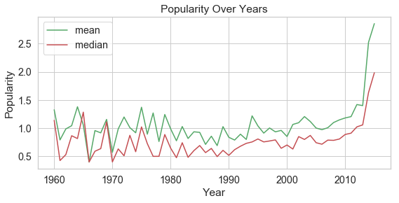

```python
#set style
sns.set_style('whitegrid')
#set x, y axis data
#x1, y1 for mean data; x2, y2 for median data
x1, y1 = index_mean, p_mean
x2, y2 = index_median, p_median
#set size
plt.figure(figsize=(9, 4))
#plot line chart for mean and median
plt.plot(x1, y1, color = 'g', label = 'mean')
plt.plot(x2, y2, color = 'r', label = 'median')
#set title and labels
plt.title('Popularity Over Years')
plt.xlabel('Year')
plt.ylabel('Popularity');
#set legend
plt.legend(loc='upper left');
```

### Question 10 : What is the relationship between runtime and vote average?

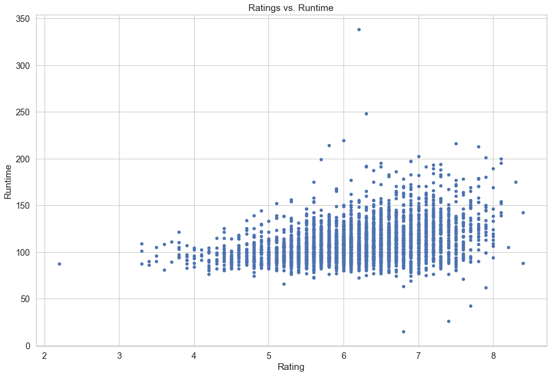

```python
# Plot scatter plot of these two columns
data.plot(x='vote_average', y='runtime', kind='scatter', figsize=(15,10))
plt.title('Ratings vs. Runtime')
plt.xlabel('Rating')
plt.ylabel('Runtime');
```

**From this scatter plot, we can draw several conclusions:**

> If it's a short film, it's likely to have a mid-to-high rating.

> The ratings of films with a runtime of around 100 minutes are unpredictable, as they can run from low to high.

## Conclusions

As i have answered the questions that i thought would be interesting to dig into, i want to wrap up all my findings in this way ....

Q. If i wanted to show one of the best and most profitable movie, what variables would i look into? Ans. I would..

Since we wanna maximize our profit, as we had shown, movies having a profit of > `$50M`, have an average budget of `$64M`. We too would keep a budget of `$64M`.

By doing these, my probability of making a profitable movie would be higher and obviously i will take care of other influential factors too. ;)

Limitations - I want to make it clear, it's not 100 percent guaranteed solution that this formula is gonna work, meaning we are going to earn more than \$50M! But it shows us that we have high probability of making high profits if we had similar characteristics as such. All these budgets and runtimes have a common trend of attraction. If we release a movie with these characteristics, it gives people higher expectations from this movie. Thus attracting more people towards the movie but it ultimately comes down to story mainly and also other important influential factors. People having higher expectations gives us less probability of meeting their expectations. Even if the movie was worth it, people's high expectations would lead in biased results ultimately effecting the profits. We also see this in real life specially in sequels of movies. This was just one example of an influential factor that would lead to different results, there are many that have to be taken care of!

And that's my conclusion!

## Bibliography

- https://carlyhochreiter.files.wordpress.com/2018/05/investigating-movie-dataset.pdf
- pandas.pydata.org
- www.programiz.com
- github.com
- https://github.com/antra0497/Udacity--Project-Investigate-TMDB-Movies-Dataset/blob/master/investigate-a-dataset-template.ipynb
- https://seaborn.pydata.org/